# Final Project

Kautilya Nalubolu

December 2, 2014

```r
# All the coulmn names are converted to more descriptive names.
colnames(NLSY79) <-  c("age.death.biological.father", "age.death.biological.mother", "CASEID", "race", "sex", "poverty.status.1978", "age.first.stopped.by.police", "ever.charged.illegal.activity", "times.charged.illegal.activity", "age.first.illegal.activity", "ever.charged.illegal.activity.adult.court", "class.worker.job.1983", "poverty.status.1987", "class.worker.job.1989", "family.net.worth.1989", "class.worker.job.1993", "times.cocaine.used", "times.crack.cocaine.used", "total.income.2000", "net.family.income.2000", "class.worker.job.2002", "total.income.2004", "family.net.worth.2004", "net.family.income.2004", "spouse.partner.2004", "age.first.marriage", "spouse.partner.2010", "family.net.worth.2008", "business.industry.type", "class.worker.job.2012", "biological.children", "total.income.2012", "net.family.income.2012", "marital.status.2012", "jobs.2012")

colnames(nlsy_ed) <- c("CASEID", "Reason.left.school", "HGC", "SAMPLE_RACE", "SAMPLE_SEX", "ENROLLMTREV79", "Highest.grade.attended", "HGC.survey year", "ENROLLMTREV89")

nlsy_ed <- data.frame(nlsy_ed)
```

```r
# The Mapvalue function is used to stardardise all the missing values as NA in both datasets.  Also, all the factors of the variables are  coded descripively
NLSY79 <- transform(NLSY79,
        age.death.biological.father = as.numeric(mapvalues(NLSY79$age.death.biological.father, c(-4, -2, -1), rep(NA, 3))),
        age.death.biological.mother = as.numeric(mapvalues(NLSY79$age.death.biological.mother, c(-4, -2, -1), rep(NA, 3))),
        Poverty.status.1978 = as.factor(mapvalues(NLSY79$poverty.status.1978, c(-3), rep("NA", 1))),
        age.first.stopped.by.police = as.numeric(mapvalues(NLSY79$age.first.stopped.by.police, c(-3, -4, -5), rep(NA, 3))),
        ever.charged.illegal.activity = as.factor(mapvalues(NLSY79$ever.charged.illegal.activity, c(-5, -3), rep("NA", 2))),
        times.charged.illegal.activity = as.numeric(mapvalues(NLSY79$times.charged.illegal.activity, c(-3, -4, -5), rep(NA, 3))),
        age.first.illegal.activity = as.factor(mapvalues(NLSY79$age.first.illegal.activity, c(-5, -4, -3), rep("NA", 3))),
        ever.charged.illegal.activity.adult.court = as.factor(mapvalues(NLSY79$ever.charged.illegal.activity.adult.court, c(-5, -4, -3), rep("NA", 3))),
        class.worker.job.1983 = as.factor(mapvalues(NLSY79$class.worker.job.1983, c(-5, -4), rep("NA", 2))),
        poverty.status.1987 = as.factor(mapvalues(NLSY79$poverty.status.1987, c(-5, -3), rep("NA", 2))),
       class.worker.job.1989 = as.factor(mapvalues(NLSY79$class.worker.job.1989, c(-5, -4, -2, -3), rep("NA", 4))),
       family.net.worth.1989 = as.factor(mapvalues(NLSY79$family.net.worth.1989, c(-5, -1), rep("NA", 2))),
      class.worker.job.1993 = as.factor(mapvalues(NLSY79$class.worker.job.1993, c(-5, -4, -2), rep("NA", 3))),
      times.cocaine.used = as.factor(mapvalues(NLSY79$times.cocaine.used, c(-5, -4, -2, -1), rep("NA", 4))),
      times.crack.cocaine.used = as.factor(mapvalues(NLSY79$times.crack.cocaine.used, c(-5, -4, -2, -1), rep("NA", 4))),
   total.income.2000 = as.numeric(mapvalues(NLSY79$total.income.2000, c(-5, -3, -2, -1), rep(NA, 4))),
  net.family.income.2000 = as.factor(mapvalues(NLSY79$net.family.income.2000, c(-5, -3, -2, -1), rep("NA", 4))),
  class.worker.job.2002 = as.factor(mapvalues(NLSY79$class.worker.job.2002, c(-5, -4, -3, -2), rep("NA", 4))),
  total.income.2004 = as.numeric(mapvalues(NLSY79$total.income.2004, c(-5, -4, -2, -1), rep(NA, 4))),
  family.net.worth.2004 = as.factor(mapvalues(NLSY79$family.net.worth.2004, c(-5, -2, -1), rep("NA", 3))),
  net.family.income.2004 = as.factor(mapvalues(NLSY79$net.family.income.2004, c(-5, -3, -2, -1), rep("NA", 4))),
  spouse.partner.2004 = as.factor(mapvalues(NLSY79$spouse.partner.2004, c(-4), rep("NA"))),
  age.first.marriage = as.factor(mapvalues(NLSY79$age.first.marriage, c(-3, -2, -1), rep("NA", 3))),
  spouse.partner.2010 = as.factor(mapvalues(NLSY79$spouse.partner.2010, c(-4), rep("NA"))),
  family.net.worth.2008 = as.factor(mapvalues(NLSY79$family.net.worth.2008, c(-5, -1), rep("NA", 2))),
  business.industry.type = as.factor(mapvalues(NLSY79$business.industry, c(-5, -4), rep("NA", 2))),
  class.worker.job.2012 = as.factor(mapvalues(NLSY79$class.worker.job.2012, c(-5, -4, -2, -1), rep("NA", 4))),
  biological.children = as.factor(mapvalues(NLSY79$biological.children, c(-5), rep("NA"))),
  total.income.2012 = as.numeric(mapvalues(NLSY79$total.income.2012, c(-5, -4, -3, -2, -1), rep(NA, 5))),
  net.family.income.2012 = as.factor(mapvalues(NLSY79$net.family.income.2012, c(-5, -2, -1), rep("NA", 3))),
  marital.status.2012 = as.factor(mapvalues(NLSY79$marital.status.2012, c(-5, -2, -1), rep("NA", 3))),
  jobs.2012 = as.factor(mapvalues(NLSY79$jobs.2012, c(-5), rep("NA"))))

NLSY79 <- transform(NLSY79,
race = as.factor(mapvalues(race, c(1, 2, 3), c("Hispanic","Black", "NonBlack NonHispanic"))),
  sex = as.factor(mapvalues(sex, c(1, 2), c("Male","Female"))),
  poverty.status.1978 = as.factor(mapvalues(poverty.status.1978, c(1, 0), c("In Poverty", "Not in Poverty"))),
  class.worker.job.1983 = as.factor(mapvalues(class.worker.job.1983, c(1, 2, 3, 4), c("Private Company", "Government", "Self Employed", "Without Pay"))),
  poverty.status.1987 = as.factor(mapvalues(poverty.status.1987, c(1, 0), c("In Poverty", "Not in Poverty"))),
  class.worker.job.1989 = as.factor(mapvalues(class.worker.job.1989, c(1, 2, 3, 4), c("Private Company", "Government", "Self Employed", "Without Pay"))),
  class.worker.job.1993 = as.factor(mapvalues(class.worker.job.1993, c(1, 2, 3, 4), c("Private Company", "Government", "Self Employed", "Without Pay"))),
  class.worker.job.2002 = as.factor(mapvalues(class.worker.job.2002, c(1, 2, 3, 4, 5), c("Government","Private For Profit", "Non Profit", "Self Employed", "Family Business"))),
  class.worker.job.2012 = as.factor(mapvalues(class.worker.job.2012, c(1, 2, 3, 4, 5), c("Government", "Private For Profit", "Non Profit", "Self Employed", "Working in Family Business"))),
  marital.status.2012 = as.factor(mapvalues(marital.status.2012, c(1, 2, 3), c("Never Married", "Married", "Other"))),
ever.charged.illegal.activity = as.factor(mapvalues(ever.charged.illegal.activity, c(1, 0), c("Yes", "No"))),
biological.children = as.factor(mapvalues(biological.children, c(-4), rep("valid skip"))))
```

```r
nlsy_ed <- transform(nlsy_ed,
  Reason.left.school = as.factor(mapvalues(nlsy_ed$Reason.left.school, c(-4, -3, -2, -1), rep("NA", 4))),
   HGC = as.factor(mapvalues(nlsy_ed$HGC, c(-4, -3, -2), rep("NA", 3))),
  ENROLLMTREV79 = as.factor(mapvalues(nlsy_ed$ENROLLMTREV79, c(-3), rep("NA"))),
  Highest.grade.attended = as.factor(mapvalues(nlsy_ed$Highest.grade.attended, c(-5, -4), rep("NA", 2))),
  HGC.survey.year = as.factor(mapvalues(nlsy_ed$HGC.survey.year, c(-5, -3), rep("NA", 2))),
  ENROLLMTREV89 = as.factor(mapvalues(nlsy_ed$ENROLLMTREV89, c(-5, -3), rep("NA", 2))))


nlsy_ed <- transform(nlsy_ed,
    Reason.left.school = as.factor(mapvalues(Reason.left.school, c(1, 2, 3, 4, 5, 6, 7, 8, 9, 10, 11, 12, 13), c("Received Degree", "GETTING MARRIED", "PREGNANCY", "OTHER REASONS DIDN'T LIKE SCHOOL", "POOR GRADES", "HOME RESPONSIBILITIES", "CHOSE TO WORK", "FINANCIAL DIFFICULTIES", "ENTERED MILITARY", "EXPELLED OR SUSPENDED", "SCHOOL TOO DANGEROUS", "MOVED AWAY FROM SCHOOL", "OTHER"))),
    HGC = as.factor(mapvalues(HGC, c(0, 1, 2, 3, 4, 5, 6, 7, 8, 9, 10, 11, 12, 13, 14, 15, 16, 17, 18, 95), c("NONE","1ST GRADE", "2ND GRADE", "3RD GRADE", "4TH GRADE", "5TH GRADE", "6TH GRADE", "7TH GRADE", "8TH GRADE", "9TH GRADE", "10TH GRADE", "11TH GRADE", "12TH GRADE", "1ST YR COL", "2ND YR COL", "3RD YR COL", "4TH YR COL", "5TH YR COL", "6TH YR COL", "UNGRADED"))),
    ENROLLMTREV79 = as.factor(mapvalues(ENROLLMTREV79, c(1, 2, 3, 4), c("NOT ENROLLED, COMPLETED LESS THAN 12TH GRADE", "ENROLLED IN HIGH SCHOOL", "ENROLLED IN COLLEGE", "NOT ENROLLED, HIGH SCHOOL GRADUATE"))),
    Highest.grade.attended = as.factor(mapvalues(Highest.grade.attended, c(6, 7, 8, 9, 10, 11, 12, 13, 14, 15, 16, 17, 18, 19, 20), c("6TH GRADE", "7TH GRADE", "8TH GRADE", "9TH GRADE", "10Th GRADE", "11TH GRADE", "12TH GRADE", "1ST YR COL", "2ND YR COL", "3RD YR COL", "4TH YR COL", "5TH YR COL", "6TH YR COL", "7TH YR COL", "8TH YR COL OR MORE"))),
    HGC.survey.year = as.factor(mapvalues(HGC.survey.year, c(0, 1, 2, 3, 4, 5, 6, 7, 8, 9, 10, 11, 12, 13, 14, 15, 16, 17, 18, 19, 20), c("NONE", "1ST GRADE", "2ND GRADE", "3RD GRADE", "4TH GRADE", "5TH GRADE", "6TH GRADE", "7TH GRADE", "8TH GRADE", "9TH GRADE", "10Th GRADE", "11TH GRADE", "12TH GRADE", "1ST YR COL", "2ND YR COL", "3RD YR COL", "4TH YR COL", "5TH YR COL", "6TH YR COL", "7TH YR COL", "8TH YR COL OR MORE"))),
    ENROLLMTREV89 = as.factor(mapvalues(ENROLLMTREV89, c(1, 2, 3, 4), c("NOT ENROLLED, COMPLETED LESS THAN 12TH GRADE", "ENROLLED IN HIGH SCHOOL", "ENROLLED IN COLLEGE", "NOT ENROLLED, HIGH SCHOOL GRADUATE"))))
```

```r
# The two different sets used are merged after this.

nlsy_merged <- merge(NLSY79, nlsy_ed, by = "CASEID")

nlsy <- data.frame(nlsy_merged)
```

```r
# Check if the data transformed correctly
str(nlsy)
```

```
## 'data.frame':    12686 obs. of  44 variables:
##  $ CASEID                                   : int  1 2 3 4 5 6 7 8 9 10 ...
##  $ age.death.biological.father              : num  NA 55 NA NA NA 54 NA NA NA NA ...
##  $ age.death.biological.mother              : num  NA NA NA NA NA NA NA 65 NA NA ...
##  $ race                                     : Factor w/ 3 levels "Black","Hispanic",..: 3 3 3 3 3 3 3 3 3 3 ...
##  $ sex                                      : Factor w/ 2 levels "Female","Male": 1 1 1 1 2 2 2 1 2 1 ...
##  $ poverty.status.1978                      : Factor w/ 3 levels "-3","In Poverty",..: 3 3 3 3 3 3 3 3 3 2 ...
##  $ age.first.stopped.by.police              : num  NA NA NA NA NA NA NA NA 15 NA ...
##  $ ever.charged.illegal.activity            : Factor w/ 3 levels "No","Yes","NA": 3 1 1 3 1 1 1 1 1 1 ...
##  $ times.charged.illegal.activity           : num  NA NA NA NA NA NA NA NA NA NA ...
##  $ age.first.illegal.activity               : Factor w/ 18 levels "10","11","12",..: 18 18 18 18 18 18 18 18 18 18 ...
##  $ ever.charged.illegal.activity.adult.court: Factor w/ 3 levels "0","1","NA": 3 3 3 3 3 3 3 3 3 3 ...
##  $ class.worker.job.1983                    : Factor w/ 5 levels "Private Company",..: 5 1 5 5 2 1 5 1 1 1 ...
##  $ poverty.status.1987                      : Factor w/ 3 levels "Not in Poverty",..: 3 1 1 1 1 1 1 3 1 1 ...
##  $ class.worker.job.1989                    : Factor w/ 5 levels "Private Company",..: 5 1 3 1 1 1 5 1 1 5 ...
```

[output cut: 30 more lines]

```r
head(nlsy)
```

```
##   CASEID age.death.biological.father age.death.biological.mother
## 1      1                          NA                          NA
## 2      2                          55                          NA
## 3      3                          NA                          NA
## 4      4                          NA                          NA
## 5      5                          NA                          NA
## 6      6                          54                          NA
##                   race    sex poverty.status.1978
## 1 NonBlack NonHispanic Female      Not in Poverty
## 2 NonBlack NonHispanic Female      Not in Poverty
## 3 NonBlack NonHispanic Female      Not in Poverty
## 4 NonBlack NonHispanic Female      Not in Poverty
## 5 NonBlack NonHispanic   Male      Not in Poverty
## 6 NonBlack NonHispanic   Male      Not in Poverty
##   age.first.stopped.by.police ever.charged.illegal.activity
```

[output cut: 97 more lines]

With this we have cleaned the data by renaming columns with descriptive names, replacing all the missing values with NA and merging two different different dataframes. Now, we have to extract relevant variables and create a data frame that can be used for our analysis.

```r
# Create a subset to run the important variables instead of using the whole dataset
nlsy_sub <- subset(nlsy, select = c(total.income.2012, race, sex, Highest.grade.attended, class.worker.job.2012, ENROLLMTREV89, biological.children))
```

Lets check the averages of income between genders and race. Non-hispanic or non-black males have higher average income compared to other race category in year 2012

```r
kable(with(nlsy_sub, tapply(total.income.2012, INDEX = list(sex, race), FUN = mean, na.rm = TRUE)), format = "markdown")
```

|  | Black | Hispanic | NonBlack NonHispanic |
| --- | --- | --- | --- |
| Female | 24095.83 | 27826.82 | 33570.33 |
| Male | 32778.96 | 46016.99 | 69113.00 |

```r
# Average income by sex
ddply(nlsy_sub, ~ sex, summarize, mean.INCOME = mean(total.income.2012, na.rm = TRUE))
```

```
##      sex mean.INCOME
## 1 Female    29538.51
## 2   Male    53445.91
```

The side by side Box plot makes it to easy to comapare the median and the variability of the incomes of males and females by race. The following graph shows 3 pairs of boxplots that are distinguished by race. We can observe that the male incomes are higher in all 3 races. However, the incomes for females are not very low. The three races referred here are Hispanic, Black, non-black or non-hispanic. Since the data was skewed, we took log to normalize the data.

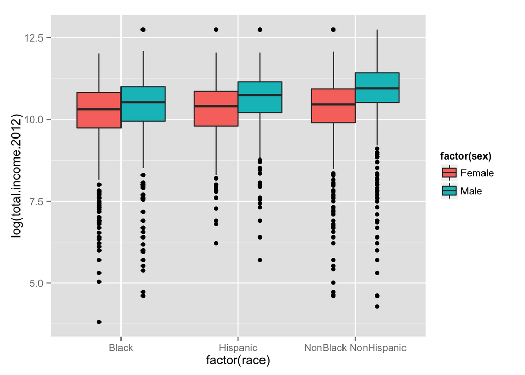

```r
# Creating side by side box plot by ggplot function to compare total income in 2012 against different levels of race of males and females
p <- ggplot(nlsy_sub, aes(factor(race), log(total.income.2012)))
p + geom_boxplot(aes(fill = factor(sex)))
```

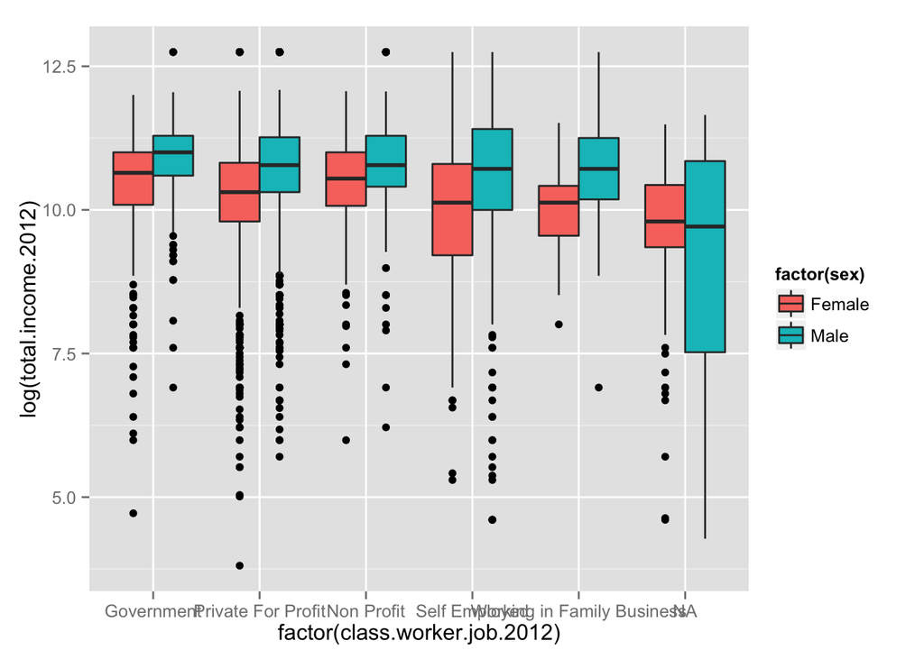

```r
# Creating side by side box plot by ggplot function to compare total income in year 2012 againt class of job between male and females
p <- ggplot(nlsy_sub, aes(factor(class.worker.job.2012), log(total.income.2012)))
p + geom_boxplot(aes(fill = factor(sex)))
```

We can see that only women have reported about biological children. Also, those that have valid skipped this question are only men and they have income higher than all the women that have reported to have kids.

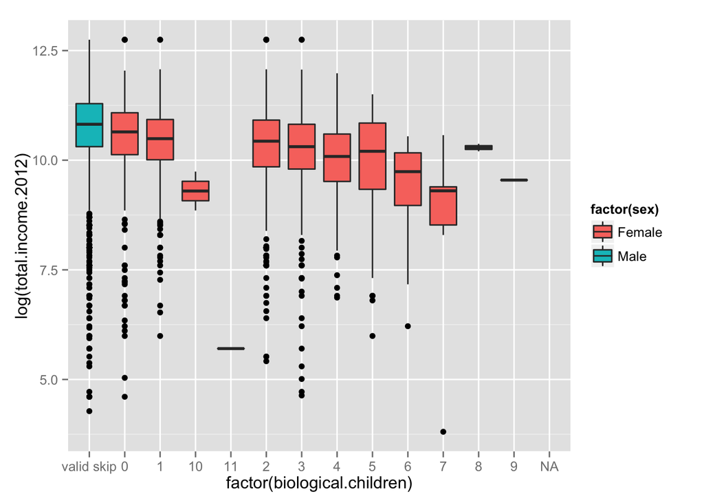

```r
# Creating side by side box plot by ggplot function to compare total income in year 2012 againt biological children between male and females
p <- ggplot(nlsy_sub, aes(factor(biological.children) , log(total.income.2012)))
p + geom_boxplot(aes(fill = factor(sex)))
```

```r
# The result showed that only females have replied to this question and males skipped this question
```

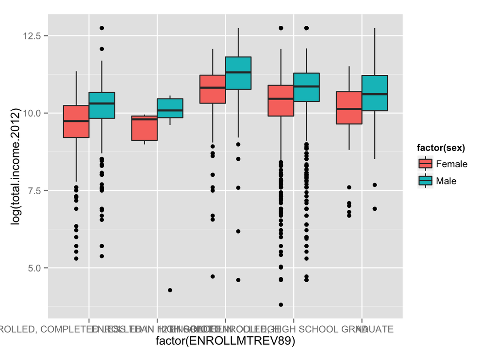

```r
p <- ggplot(nlsy_sub, aes(factor(ENROLLMTREV89) , log(total.income.2012)))
p + geom_boxplot(aes(fill = factor(sex)))
```

```r
# Total income is negatively correlated with illegal activity variable
with(nlsy, cor(times.charged.illegal.activity, total.income.2012, use = "complete"))
```

```
## [1] -0.1217259
```

```r
# Run linear regression
nlsy_sub[nlsy_sub == 0] <- NA
is.na(nlsy_sub) <- do.call(cbind,lapply(nlsy_sub, is.infinite))
nlsy_sub <- transform(nlsy_sub, total.income = log(total.income.2012), na.rm = TRUE)
 total.income.lm <- lm(total.income ~ ., data = nlsy_sub)
 total.income.lm
```

```
##
## Call:
## lm(formula = total.income ~ ., data = nlsy_sub)
##
## Coefficients:
##                                     (Intercept)
##                                       8.893e+00
##                               total.income.2012
##                                       1.217e-05
##                                    raceHispanic
##                                       1.367e-01
##                        raceNonBlack NonHispanic
##                                       1.026e-01
##                                         sexMale
##                                       3.485e-01
##                Highest.grade.attended12TH GRADE
##                                       4.807e-01
##                Highest.grade.attended1ST YR COL
##                                       6.280e-01
##                Highest.grade.attended2ND YR COL
##                                       7.217e-01
##                Highest.grade.attended3RD YR COL
##                                       4.859e-01
##                Highest.grade.attended4TH YR COL
##                                       5.524e-01
##                Highest.grade.attended5TH YR COL
##                                       4.040e-01
##                Highest.grade.attended6TH YR COL
##                                       6.730e-01
##                Highest.grade.attended7TH YR COL
##                                       4.124e-01
##        Highest.grade.attended8TH YR COL OR MORE
##                                      -1.503e-01
##                 Highest.grade.attended6TH GRADE
##                                       7.308e-01
##                 Highest.grade.attended7TH GRADE
##                                       6.148e-01
##                 Highest.grade.attended9TH GRADE
##                                       9.332e-01
##                        Highest.grade.attendedNA
```

[output cut: 28 more lines]

```
##                                       1.765e-01
##                            biological.children4
##                                       8.208e-02
##                            biological.children5
##                                      -6.714e-02
##                            biological.children6
##                                      -2.148e-01
##                            biological.children7
##                                      -1.060e+00
##                            biological.children8
##                                       4.527e-01
##                            biological.children9
##                                              NA
##                                       na.rmTRUE
##                                              NA
```

```r
summary(lm(total.income ~ ., data = nlsy_sub))
```

```
##
## Call:
## lm(formula = total.income ~ ., data = nlsy_sub)
##
## Residuals:
##     Min      1Q  Median      3Q     Max
## -5.1013 -0.1017  0.1896  0.3576  1.9640
##
## Coefficients: (2 not defined because of singularities)
##                                                   Estimate Std. Error
## (Intercept)                                      8.893e+00  7.756e-01
## total.income.2012                                1.217e-05  1.815e-07
## raceHispanic                                     1.367e-01  2.989e-02
## raceNonBlack NonHispanic                         1.026e-01  2.386e-02
## sexMale                                          3.485e-01  6.936e-01
## Highest.grade.attended12TH GRADE                 4.807e-01  3.882e-01
## Highest.grade.attended1ST YR COL                 6.280e-01  3.595e-01
## Highest.grade.attended2ND YR COL                 7.217e-01  3.623e-01
## Highest.grade.attended3RD YR COL                 4.859e-01  3.707e-01
## Highest.grade.attended4TH YR COL                 5.524e-01  3.601e-01
## Highest.grade.attended5TH YR COL                 4.040e-01  3.672e-01
## Highest.grade.attended6TH YR COL                 6.730e-01  3.717e-01
## Highest.grade.attended7TH YR COL                 4.124e-01  4.029e-01
## Highest.grade.attended8TH YR COL OR MORE        -1.503e-01  4.079e-01
## Highest.grade.attended6TH GRADE                  7.308e-01  7.758e-01
## Highest.grade.attended7TH GRADE                  6.148e-01  6.417e-01
## Highest.grade.attended9TH GRADE                  9.332e-01  6.109e-01
## Highest.grade.attendedNA                         5.203e-01  3.472e-01
## class.worker.job.2012Private For Profit         -1.741e-01  2.638e-02
## class.worker.job.2012Non Profit                 -9.822e-02  4.138e-02
## class.worker.job.2012Self Employed              -4.823e-01  3.913e-02
## class.worker.job.2012Working in Family Business -4.153e-01  9.707e-02
## class.worker.job.2012NA                         -8.226e-01  6.961e-02
## ENROLLMTREV89ENROLLED IN HIGH SCHOOL            -4.446e-01  2.275e-01
## ENROLLMTREV89ENROLLED IN COLLEGE                 2.419e-01  5.135e-02
## ENROLLMTREV89NOT ENROLLED, HIGH SCHOOL GRADUATE  2.614e-01  3.246e-02
## ENROLLMTREV89NA                                  1.891e-01  6.701e-02
## biological.children1                             2.642e-01  6.943e-01
## biological.children10                           -1.677e-01  8.490e-01
## biological.children11                           -2.891e+00  9.823e-01
```

[output cut: 41 more lines]

```
## biological.children3                              0.254  0.79933
## biological.children4                              0.118  0.90603
## biological.children5                             -0.096  0.92347
## biological.children6                             -0.303  0.76179
## biological.children7                             -1.416  0.15669
## biological.children8                              0.533  0.59378
## biological.children9                                 NA       NA
## na.rmTRUE                                            NA       NA
## ---
## Signif. codes:  0 '***' 0.001 '**' 0.01 '*' 0.05 '.' 0.1 ' ' 1
##
## Residual standard error: 0.6927 on 4820 degrees of freedom
##   (7829 observations deleted due to missingness)
## Multiple R-squared:  0.5726, Adjusted R-squared:  0.5694
## F-statistic: 179.4 on 36 and 4820 DF,  p-value: < 2.2e-16
```

Missing values were replaced with NA using transform function and latter ommitted. I also included the education variables to understand the effect of education on the income.

I am not confident enough about the analysis. I believe that it is quite preliminary and might need to use different regression methods to better understand the correlations between the variables. Also, I feel that I have considered very few variables and might be biased.